# Concrete compressive strength prediction with machine learning

Pedro Bernardino Alves Moreira

April 22, 2020

Abstract

# 1 Introduction

Compressive strength is the main characteristic of concrete, measured by tests of international standards that consist of the breaking of specimens. Measurement at 28 days is mandatory and represents the grade of the concrete. Knowing in advance what the result will be obtained for a given age, based on the proportions of its ingredients, is of great interest to concrete manufacturers, construction companies, and civil engineers.

This compressive strength is a nonlinear function of its ingredients and age, making it difficult to establish an analytical formula, although some formulas have already been proposed. Hasan (2011) proposed a mathematical model to predict from the results of tests of 7 and 14 days, and Kabir (2012) from 7 days. However, machine learning techniques can be used to model this characteristic from real sample data, using only the ingredients.

Unlike previous studies with this dataset, this work does data preparation differently. The age of the concrete is the most unique feature that contributes to its compressive strength. For this reason, age is treated separately in the machine learning models, creating models for each age group.

# 2 Materials and Methods

## 2.1 Materials

The methodology was carried out using RStudio software (RStudio Team 2020), an integrated virtual environment for code development in *R* (R Core Team 2020). Throughout the process, all code executed was documented in the same order as its execution in Appendix 3, and reference was always made to codes throughout the text. All relevant information related to the operating system and installed packages has been presented in Appendix 1. In addition, an online and open-source repository was created in *Github*, housing all the code used to generate this work, the link was made available in Appendix 2.

## 2.2 Reproducibility

In order to guarantee reproducibility, whenever there was some code that could use probabilistic operations, a *seed* was defined before its execution, ensuring that when run on another machine, with the same version of *R* and the same *seed*, get the same result. The *seeds* can be checked throughout Appendix 3 or directly on *Github*.

## 2.3 Obtaining the data

Table 2.1: First 6 samples

| ID | Cement $kg/m^3$ | B.F.S. $kg/m^3$ | Fly ash $kg/m^3$ | Water $kg/m^3$ | Superp. $kg/m^3$ | C.Aggregate $kg/m^3$ | F.Aggregate $kg/m^3$ | Day | Comp.Str. $MPa$ |
| --- | --- | --- | --- | --- | --- | --- | --- | --- | --- |
| 1 | 540.0 | 0.0 | 0 | 162 | 2.5 | 1040.0 | 676.0 | 28 | 79.99 |
| 2 | 540.0 | 0.0 | 0 | 162 | 2.5 | 1055.0 | 676.0 | 28 | 61.89 |
| 3 | 332.5 | 142.5 | 0 | 228 | 0.0 | 932.0 | 594.0 | 270 | 40.27 |
| 4 | 332.5 | 142.5 | 0 | 228 | 0.0 | 932.0 | 594.0 | 365 | 41.05 |
| 5 | 198.6 | 132.4 | 0 | 192 | 0.0 | 978.4 | 825.5 | 360 | 44.30 |
| 6 | 266.0 | 114.0 | 0 | 228 | 0.0 | 932.0 | 670.0 | 90 | 47.03 |

## 2.4 Data preparation

The preparation of the data consisted of transforming the sample set in order to maintain only relevant data for the subsequent studies. Data that were considered irrelevant or that had the potential to add undesirable noise to the analysis were removed. In addition, the relevant data has been transformed to better fit the studies in the next steps.

### 2.4.1 Initial data cleaning

Initially, there were 25 duplicate samples that were removed, resulting in a new total of 1005 samples ().

The data show the variables in the columns and samples in the rows. However it was found that some samples are identical in proportions of ingredients, changing only the value of age and compressive strngth, for example, samples 653, 654, 678 and 681, shown in the table .

Table 2.2: Samples with same composition

| ID | Cement $kg/m^3$ | B.F.S. $kg/m^3$ | Fly ash $kg/m^3$ | Water $kg/m^3$ | Superp. $kg/m^3$ | C.Aggregate $kg/m^3$ | F.Aggregate $kg/m^3$ | Day | Comp.Str. $MPa$ |
| --- | --- | --- | --- | --- | --- | --- | --- | --- | --- |
| 653 | 102 | 153 | 0 | 192 | 0 | 887 | 942 | 3 | 4.57 |
| 678 | 102 | 153 | 0 | 192 | 0 | 887 | 942 | 7 | 7.68 |
| 681 | 102 | 153 | 0 | 192 | 0 | 887 | 942 | 28 | 17.28 |
| 654 | 102 | 153 | 0 | 192 | 0 | 887 | 942 | 90 | 25.46 |

In addition, there are also samples with the same values and proportions of ingredients, but with different compressive strength, probably due to differences in the building process. This is the case, for example, of samples 472, 473 and 474, shown in the table .

Table 2.3: Same samples with different results

| ID | Cement $kg/m^3$ | B.F.S. $kg/m^3$ | Fly ash $kg/m^3$ | Water $kg/m^3$ | Superp. $kg/m^3$ | C.Aggregate $kg/m^3$ | F.Aggregate $kg/m^3$ | Day | Comp.Str. $MPa$ |
| --- | --- | --- | --- | --- | --- | --- | --- | --- | --- |
| 472 | 446 | 24 | 79 | 162 | 11.6 | 967 | 712 | 28 | 57.03 |
| 473 | 446 | 24 | 79 | 162 | 11.6 | 967 | 712 | 28 | 44.42 |
| 474 | 446 | 24 | 79 | 162 | 11.6 | 967 | 712 | 28 | 51.02 |

To facilitate the analysis of the samples, all samples that are the same in relation to the ingredients, have been assigned the same *id*. In addition, as the compressive strength at 28 days is the parameter to determine the grade of the concrete, only the elements containing that day among its samples were maintained. In the case of the same samples but with different results of compressive strength, the values were averaged. After all these changes (), the new total of samples was reduced to 970, containing 416 different settings for the proportions of ingredients.

The result can be seen in the table . All samples with equal ingredient settings have the same id, and when they had different results for the same days, they were transformed into just one sample, with the arithmetic mean in the compressive strength.

Table 2.4: Previous samples after processing

| ID | Cement $kg/m^3$ | B.F.S. $kg/m^3$ | Fly ash $kg/m^3$ | Water $kg/m^3$ | Superp. $kg/m^3$ | C.Aggregate $kg/m^3$ | F.Aggregate $kg/m^3$ | Day | Comp.Str. $MPa$ |
| --- | --- | --- | --- | --- | --- | --- | --- | --- | --- |
| 472 | 446 | 24 | 79 | 162 | 11.6 | 967 | 712 | 28 | 50.82 |
| 653 | 102 | 153 | 0 | 192 | 0.0 | 887 | 942 | 3 | 4.57 |
| 653 | 102 | 153 | 0 | 192 | 0.0 | 887 | 942 | 7 | 7.68 |
| 653 | 102 | 153 | 0 | 192 | 0.0 | 887 | 942 | 28 | 17.28 |
| 653 | 102 | 153 | 0 | 192 | 0.0 | 887 | 942 | 90 | 25.46 |

### 2.4.2 Age selection

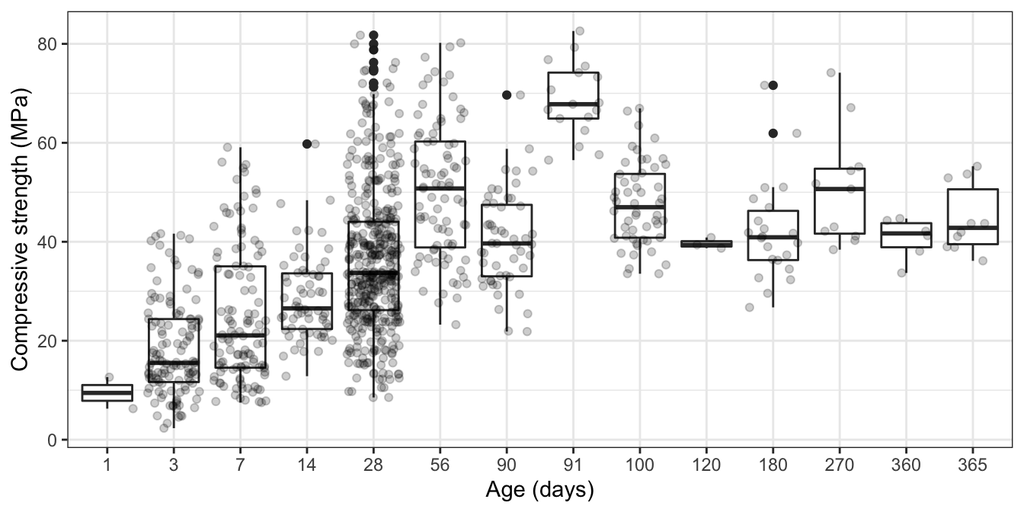

Figure 2.1: Boxplot - Compressive strength (MPa) vs age (days)

It was observed that the ages of 90, 91 and 100 days probably represent extremes to each other in the ingredient configurations, since they are relatively close ages but with very different values, especially for 90 and 91.

This hypothesis was verified using the principal component analysis method, applied to samples of these 3 ages (). The figure shows how the samples relate to each other (which are similar or different) and revealed how each variable contributes to the analysis. The first two dimensions represent $ 37 % $ and $ 24 % $ respectively of the variance.

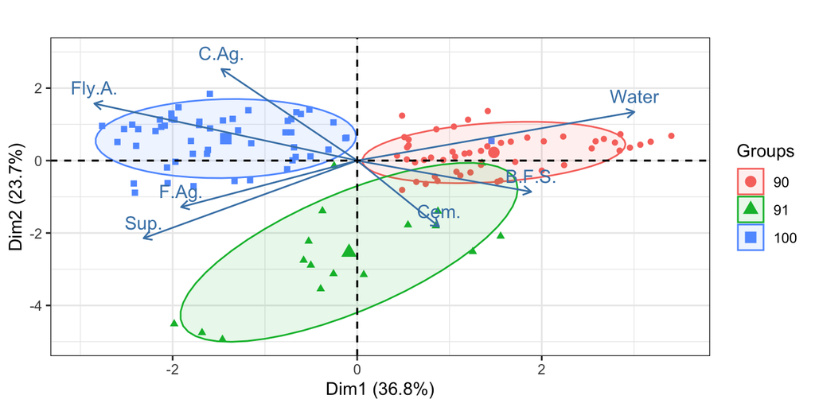

Figure 2.2: Principal component analysis - 90, 91 e 100 days

Another important point considered, of the concrete nature itself, is the fact that the growth rate of its compressive strength decreases with time, reaching a certain stability value. The figure shows the compressive strength over the days for samples with more than 5 data, that is, data available for at least 6 different ages ().

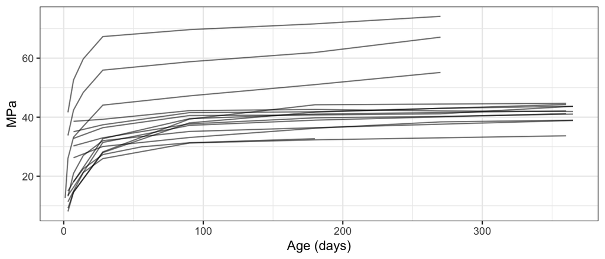

Figure 2.3: Compressive strength through time

For the reasons presented in the figures , and , it was considered that the ages of 90, 91 and 100 days can be grouped to improve reading and decrease sample noise. They were converted to the same value, the age of 100 days was chosen (. As shown in the figure , the resistance only increases, after 100 days the resistance to compression will be greater than or equal to the value of 90 or 91 days.

Another topic analyzed in the selection of ages was the observed frequency of each age value after this transformation from 90, 91 in 100 days, shown in the figure . Some values of days have very low concentrations of samples, at the risk of damaging more than helping to create the models, so they were removed (). The criterion adopted was to maintain only ages with a frequency greater than 50, only the values of 3, 7, 14, 28, 56 and 100 days.

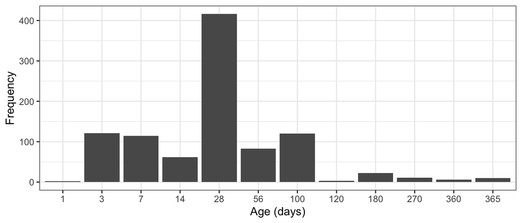

Figure 2.4: Ages frequency

### 2.4.3 Data reorganization

The samples were grouped to maintain only a separate sample from each set of configuration of the proportions of the ingredients, adding new variables/columns for resistance at each age (). The result in the first samples after this processing is shown in the table .

Table 2.5: First 6 samples after reorganization

| ID | Cement $kg/m^3$ | B.F.S $kg/m^3$ | Fly ash $kg/m^3$ | Water $kg/m^3$ | Superp. $kg/m^3$ | Coarse Ag. $kg/m^3$ | Fine Ag. $kg/m^3$ | 3 days $MPa$ | 7 days $MPa$ | 14 days $MPa$ | 28 days $MPa$ | 56 days $MPa$ | 100 days $MPa$ |
| --- | --- | --- | --- | --- | --- | --- | --- | --- | --- | --- | --- | --- | --- |
| 1 | 540.0 | 0.0 | 0 | 162 | 2.5 | 1040.0 | 676.0 |  |  |  | 79.99 |  |  |
| 2 | 540.0 | 0.0 | 0 | 162 | 2.5 | 1055.0 | 676.0 |  |  |  | 61.89 |  |  |
| 3 | 332.5 | 142.5 | 0 | 228 | 0.0 | 932.0 | 594.0 |  | 30.28 |  | 33.02 |  | 37.72 |
| 5 | 198.6 | 132.4 | 0 | 192 | 0.0 | 978.4 | 825.5 | 9.13 | 14.64 |  | 28.02 |  | 38.07 |
| 6 | 266.0 | 114.0 | 0 | 228 | 0.0 | 932.0 | 670.0 |  |  |  | 45.85 |  | 47.03 |
| 7 | 380.0 | 95.0 | 0 | 228 | 0.0 | 932.0 | 594.0 |  | 32.82 |  | 36.45 |  | 40.56 |

The number of samples and distinct samples after all this manipulation remained the same, a total of 416 ().

### 2.4.4 Adding new variables

Table 2.6: New features

| ID | Class | Approximated Mix | Water / Cement | Fine Ag. / Cement | Coarse Ag. / Cement | Fine Ag. / Coarse Ag. | Water / Coarse Ag. | Water / Fine Ag. |
| --- | --- | --- | --- | --- | --- | --- | --- | --- |
| 1 | C75 | 1:1:2 | 0.3000 | 1.2519 | 1.9259 | 0.6500 | 0.1558 | 0.2396 |
| 2 | C60 | 1:1:2 | 0.3000 | 1.2519 | 1.9537 | 0.6408 | 0.1536 | 0.2396 |
| 3 | C30 | 1:2:3 | 0.6857 | 1.7865 | 2.8030 | 0.6373 | 0.2446 | 0.3838 |
| 5 | C25 | 1:4:5 | 0.9668 | 4.1566 | 4.9265 | 0.8437 | 0.1962 | 0.2326 |
| 6 | C45 | 1:3:4 | 0.8571 | 2.5188 | 3.5038 | 0.7189 | 0.2446 | 0.3403 |
| 7 | C35 | 1:2:2 | 0.6000 | 1.5632 | 2.4526 | 0.6373 | 0.2446 | 0.3838 |

## 2.5 Data visualization

In order to assess the need for further manipulation before building the models, in this step the 416 samples already processed were visualized and analyzed.

### 2.5.1 Descriptive statistics

Table 2.7: Descriptive statistics - continuous variables

|  | Samples | Null | NA | Min | Max | Range | Sum | Median | Mean | SE mean | CI mean | Variance | Std.Dev. | Coef.Var |
| --- | --- | --- | --- | --- | --- | --- | --- | --- | --- | --- | --- | --- | --- | --- |
| Cement | 416 | 0 | 0 | 102.00 | 540.00 | 438.00 | 109373.10 | 257.70 | 262.92 | 5.10 | 10.02 | 10817.50 | 104.01 | 0.40 |
| B.F.S. | 416 | 174 | 0 | 0.00 | 359.40 | 359.40 | 35824.60 | 94.25 | 86.12 | 4.32 | 8.49 | 7755.00 | 88.06 | 1.02 |
| Fly ash | 416 | 202 | 0 | 0.00 | 200.10 | 200.10 | 26389.00 | 71.25 | 63.44 | 3.26 | 6.40 | 4407.81 | 66.39 | 1.05 |
| Water | 416 | 0 | 0 | 121.80 | 247.00 | 125.20 | 76335.60 | 185.00 | 183.50 | 0.94 | 1.86 | 370.73 | 19.25 | 0.10 |
| Superplast. | 416 | 107 | 0 | 0.00 | 32.20 | 32.20 | 2871.30 | 7.60 | 6.90 | 0.26 | 0.52 | 28.85 | 5.37 | 0.78 |
| Coarse agg. | 416 | 0 | 0 | 801.00 | 1145.00 | 344.00 | 397799.90 | 953.35 | 956.25 | 4.12 | 8.10 | 7063.06 | 84.04 | 0.09 |
| Fine agg. | 416 | 0 | 0 | 594.00 | 992.60 | 398.60 | 317809.80 | 769.65 | 763.97 | 3.59 | 7.06 | 5371.89 | 73.29 | 0.10 |
| 3 days | 121 | 0 | 295 | 2.33 | 41.64 | 39.31 | 2210.82 | 15.52 | 18.27 | 0.87 | 1.72 | 91.64 | 9.57 | 0.52 |
| 7 days | 114 | 0 | 302 | 7.51 | 59.09 | 51.58 | 2845.52 | 21.06 | 24.96 | 1.29 | 2.55 | 188.81 | 13.74 | 0.55 |
| 14 days | 62 | 0 | 354 | 12.84 | 59.76 | 46.92 | 1782.56 | 26.54 | 28.75 | 1.10 | 2.19 | 74.62 | 8.64 | 0.30 |
| 28 days | 416 | 0 | 0 | 8.54 | 81.75 | 73.21 | 15101.13 | 33.72 | 36.30 | 0.70 | 1.38 | 206.30 | 14.36 | 0.40 |
| 56 days | 83 | 0 | 333 | 23.25 | 80.20 | 56.95 | 4178.77 | 50.77 | 50.35 | 1.52 | 3.02 | 190.82 | 13.81 | 0.27 |
| 100 days | 120 | 0 | 296 | 21.86 | 82.60 | 60.74 | 5701.90 | 45.61 | 47.52 | 1.17 | 2.31 | 163.40 | 12.78 | 0.27 |
| Water / Cement | 416 | 0 | 0 | 0.27 | 1.88 | 1.62 | 340.60 | 0.73 | 0.82 | 0.02 | 0.03 | 0.11 | 0.34 | 0.41 |
| Fine agg. / Cement | 416 | 0 | 0 | 1.14 | 9.24 | 8.10 | 1415.82 | 2.94 | 3.40 | 0.07 | 0.14 | 1.96 | 1.40 | 0.41 |
| Coarse agg. / Cement | 416 | 0 | 0 | 1.55 | 8.70 | 7.14 | 1761.06 | 3.67 | 4.23 | 0.08 | 0.16 | 2.70 | 1.64 | 0.39 |
| Fine agg. / Coarse agg. | 416 | 0 | 0 | 0.53 | 1.16 | 0.63 | 335.42 | 0.80 | 0.81 | 0.01 | 0.01 | 0.01 | 0.11 | 0.14 |
| Water / Coarse agg. | 416 | 0 | 0 | 0.12 | 0.29 | 0.17 | 80.66 | 0.19 | 0.19 | 0.00 | 0.00 | 0.00 | 0.03 | 0.16 |
| Water / Fine agg. | 416 | 0 | 0 | 0.13 | 0.38 | 0.26 | 101.26 | 0.24 | 0.24 | 0.00 | 0.00 | 0.00 | 0.04 | 0.17 |

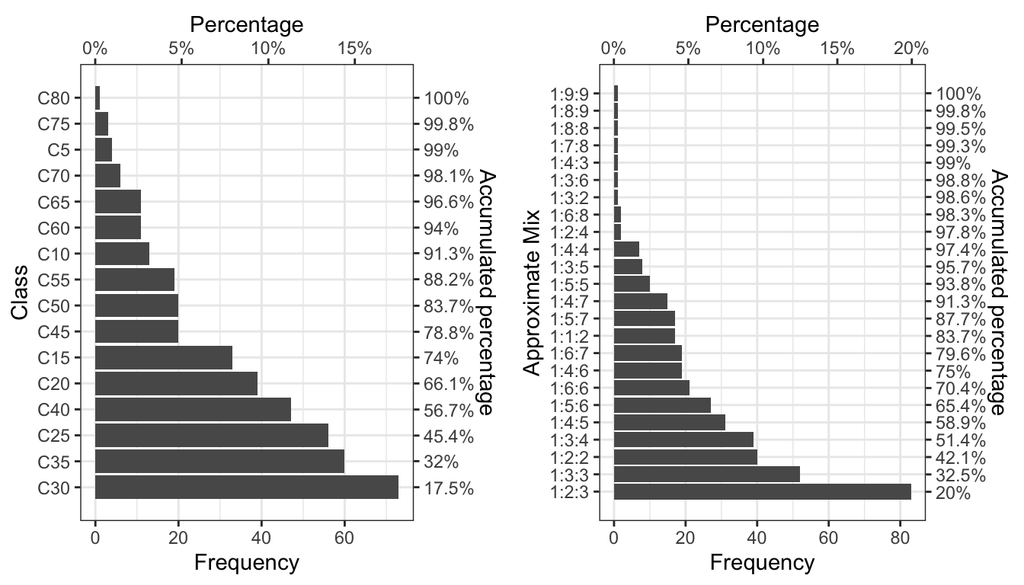

Figure 2.5: Descriptive statistics - categorical variables

### 2.5.2 Correlation between ingredients and compressive strength

The figure shows the correlation of variables for each set of ages (). The figure presents the same data, but instead of correlating them all, it only correlates with the compressive strength, showing the values in more detail ().

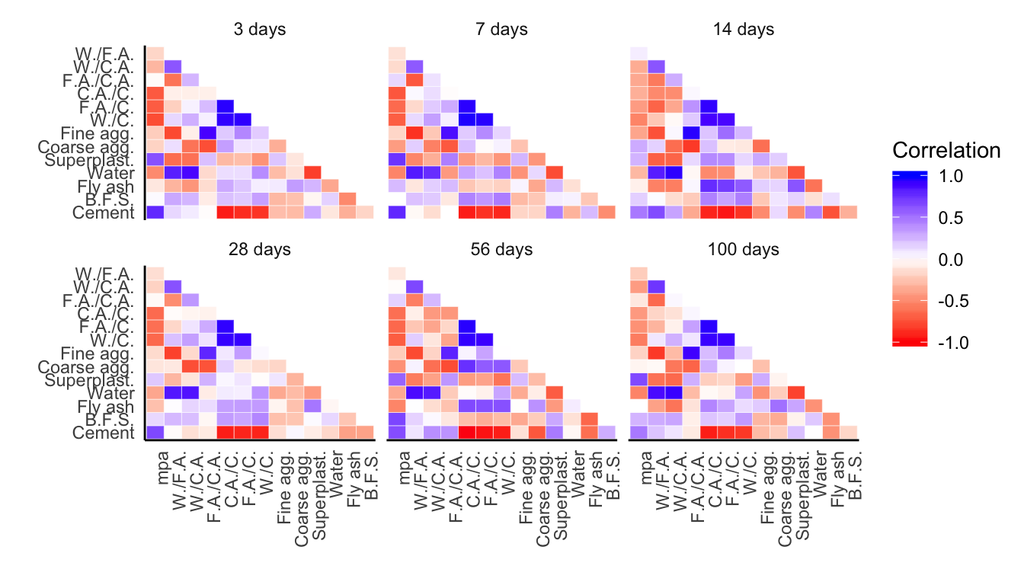

Figure 2.6: Correlations at each age

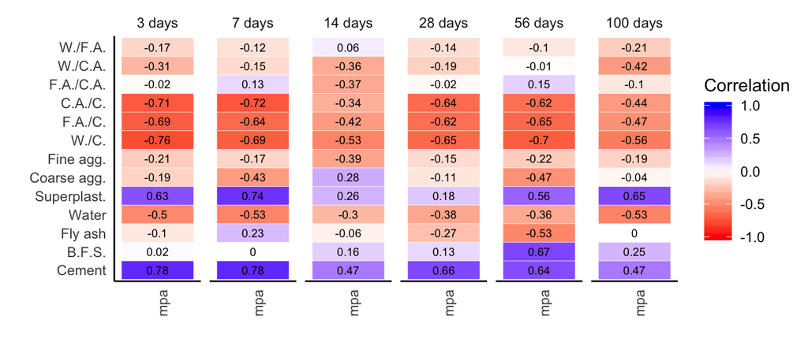

Figure 2.7: Correlation of variables with compressive strength over time

The interpretation of the figure suggests that the strength of the concrete is positively related mainly to the cement and superplasticizer ingredients and negatively to the water and fine aggregate. The smaller the amount of cement for aggregates and water, the more negatively they are correlated with compressive strength.

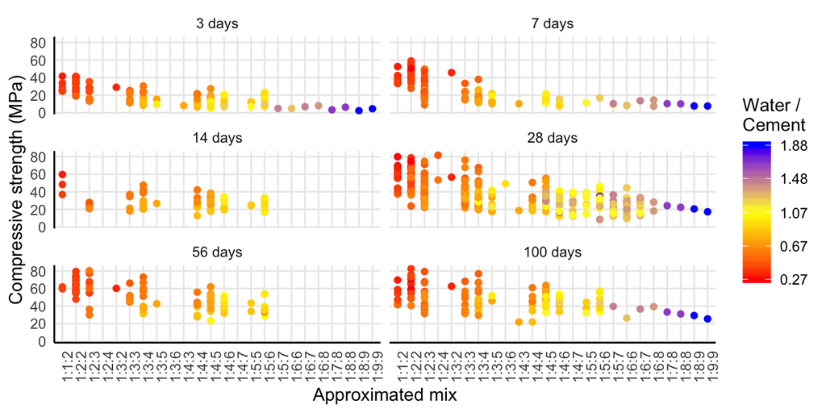

Figure 2.8: Relationship between approximated mix, water, MPa and age

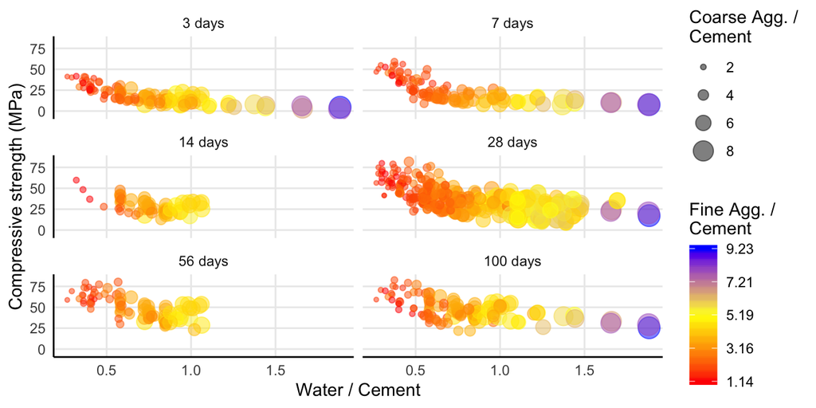

Figure 2.9: Relationship between concrete main features

The figures and show the relationship between the main ingredients (known as mix) in relation to the compressive strength ( and ). The interpretation of these figures shows that the greater the amount of cement in relation to the other ingredients, the greater the resistance to compression.

### 2.5.3 Variables distribution

A figura mostra a distribuição das variáveis nas amostras (). Foi calculado utilizando apenas os dados aos 28 dias. The figure shows the distribution of variables in the samples (). It was calculated using data only at 28 days.

[figure not shown]

Figure 2.10: Variables distribution

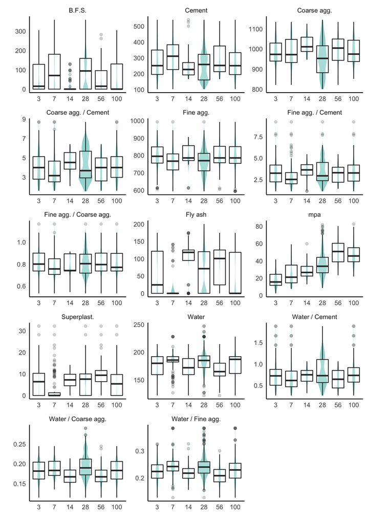

Figure 2.11: Variables distribution grouped by age

### 2.5.4 Principal component analysis

Na figura , utilizando uma classificação alternativa, foi realizada a análise de componente principal nos ingredientes das amostras (). A classificação separa o concreto em 4 grupos de resistência a compressão diferentes, baixo até $20 MPa$, normal até $40 MPa$, médio até $70 MPa$ e alto acima disso. É possivel perceber que os grupos se sobrepõem, mas existem uma diferenciação entre o grupo alto e baixo. In the figure v, using an alternative classification, the principal component analysis was performed on the ingredients (). The classification separates concrete into 4 different compressive strength groups, low up to *20 MPa*, normal up to *40 MPa*, medium up to *70 MPa* and high above that. It is possible to notice that the groups overlap, but there is a differentiation between the high and low group.

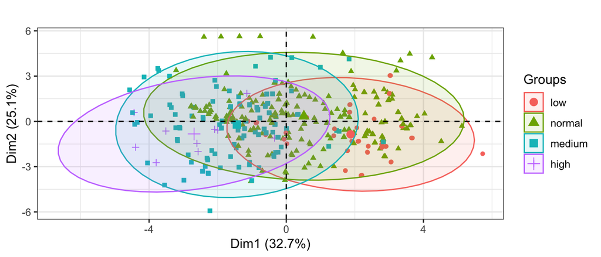

Figure 2.12: Principal component analysis on ingredients

## 2.6 Machine learning models

The development of machine learning models was carried out with the *caret* package (Kuhn 2020) and based on Irizarry (2019) e Kuhn (2008).

### 2.6.1 Pre-processing and data separation

Table 2.8: First 18 columns of the 6 first samples of 28 days

| ID | Cement $kg/m^3$ | B.F.S. $kg/m^3$ | Fly ash $kg/m^3$ | water $kg/m^3$ | Superp. $kg/m^3$ | Coarse Agg. $kg/m^3$ | Fine Agg. $kg/m^3$ | MPa $MPa$ | Class | Wat./ Ci. | F.Agg./ Ce. | C.Agg./ Ce. | F.Agg./ C.Agg. | Wat./ C.Agg. | Wat./ F.Agg. | App Mix 1:1:2 | App Mix 1:2:2 |
| --- | --- | --- | --- | --- | --- | --- | --- | --- | --- | --- | --- | --- | --- | --- | --- | --- | --- |
| 1 | 540.0 | 0.0 | 0 | 162 | 2.5 | 1040.0 | 676.0 | 79.99 | C75 | 0.30 | 1.25 | 1.93 | 0.65 | 0.16 | 0.24 | 1 | 0 |
| 2 | 540.0 | 0.0 | 0 | 162 | 2.5 | 1055.0 | 676.0 | 61.89 | C60 | 0.30 | 1.25 | 1.95 | 0.64 | 0.15 | 0.24 | 1 | 0 |
| 3 | 332.5 | 142.5 | 0 | 228 | 0.0 | 932.0 | 594.0 | 33.02 | C30 | 0.69 | 1.79 | 2.80 | 0.64 | 0.24 | 0.38 | 0 | 0 |
| 5 | 198.6 | 132.4 | 0 | 192 | 0.0 | 978.4 | 825.5 | 28.02 | C25 | 0.97 | 4.16 | 4.93 | 0.84 | 0.20 | 0.23 | 0 | 0 |
| 6 | 266.0 | 114.0 | 0 | 228 | 0.0 | 932.0 | 670.0 | 45.85 | C45 | 0.86 | 2.52 | 3.50 | 0.72 | 0.24 | 0.34 | 0 | 0 |
| 7 | 380.0 | 95.0 | 0 | 228 | 0.0 | 932.0 | 594.0 | 36.45 | C35 | 0.60 | 1.56 | 2.45 | 0.64 | 0.24 | 0.38 | 0 | 1 |

The stage of centralization and normalization of the variables was carried out later, together with the application of the models, as it is simpler to do this with the *caret* package. If performed at this time, it would be necessary to manually undo these transformations in the predictions. The *caret* allows you to transform before training the models and already transforms the results back.

Each data set was separated into test and training sets, *20%* and *80%* respectively (). The figure shows the distribution of data between the sets in relation to the compressive strength for each model ().

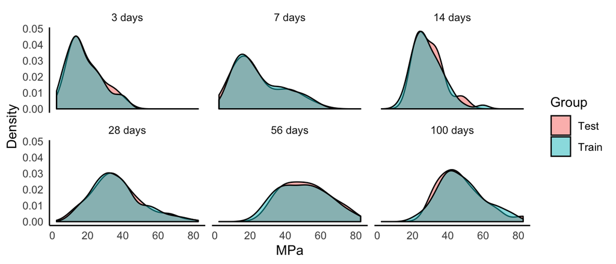

Figure 2.13: Distribution of test and train data

### 2.6.2 Performance measures

The performance evaluation of the models was performed by the Root Mean Square Error (*RMSE*). The *RMSE* is the measure used in all the works mentioned in the introduction and will allow the comparison of the models in the discussion.

### 2.6.3 Naive models

Before creating the real models, for comparison purposes, naive models were created. They simply predict that the compressive strength of the test set is the average compressive strength of the training set (). In other words, naive models are simply the best guess possible. The results can be checked in the table .

Table 2.9: Naive models

| Age | Mean $MPa$ (train) | RMSE (train) | RMSE (test) |
| --- | --- | --- | --- |
| 3 | 18.08887 | 9.591344 | 9.303229 |
| 7 | 25.12383 | 13.731569 | 13.443646 |
| 14 | 28.63980 | 8.786823 | 7.593319 |
| 28 | 36.33605 | 14.361021 | 14.283824 |
| 56 | 50.06555 | 13.968077 | 12.702112 |
| 100 | 47.57000 | 12.758042 | 12.614652 |

### 2.6.4 Choice of algorithms

The *caret* (Kuhn 2020) package exposes more than 200 different algorithms for building *machine learning* models. The package documentation presents an initial code (“Models Clustered by Tag Similarity” 2020) as a suggestion to select a portfolio of the most distinct algorithms possible in relation to some pre-selected algorithm, but for agility and due to technical limitations, it was chosen to use an algorithm with the highest probability to achieve the best possible result. According to Fernandez-Delgado et al. (2014), who compared 179 algorithms in 121 different databases, the algorithm most likely to achieve the best possible results is the *Parallel Random Forest* (called *prRF* in *caret*).

# 3 Literature cited

Abban, Daniel. 2016. “Concrete Compresive Strength.” October 2016. https://rpubs.com/brother_abban/220101.

Alshamiri, Tian-Feng e Kim, Abobakr e Yuan. 2020. “Non-Tuned Machine Learning Approach for Predicting the Compressive Strength of High-Performance Concrete.” *Materials* 13 (February): 1023. https://doi.org/10.3390/ma13051023.

“Concrete Compressive Strength Data Set.” 2008. University of California Irvine. March 2008. https://archive.ics.uci.edu/ml/datasets/concrete+compressive+strength.

Fernandez-Delgado, Manuel, E. Cernadas, S. Barro, and Dinani Amorim. 2014. “Do We Need Hundreds of Classifiers to Solve Real World Classification Problems?” *Journal of Machine Learning Research* 15 (October): 3133–81.

Hameed, Mohamed, Mohammed e Khalid. 2020. “Prediction of Compressive Strength of High-Performance Concrete: Hybrid Artificial Intelligence Technique.” In, 323–35. https://doi.org/10.1007/978-3-030-38752-5_26.

Hasan, Ahsanul, Md e Kabir. 2011. “Prediction of Compressive Strength of Concrete from Early Age Test Result.” In. https://doi.org/10.13140/RG.2.1.3270.7684.

Irizarry, R.A. 2019. *Introduction to Data Science: Data Analysis and Prediction Algorithms with R*. Chapman & Hall/Crc Data Science Series. CRC Press. https://books.google.com.br/books?id=xb29DwAAQBAJ.

Kabir, Md e Miah, Ahsanul e Hasan. 2012. “Predicting 28 Days Compressive Strength of Concrete from 7 Days Test Result,” January, 18–22.

Kuhn, Max. 2008. “Building Predictive Models in R Using the Caret Package.” *Journal of Statistical Software, Articles* 28 (5). https://doi.org/10.18637/jss.v028.i05.

Kuhn, Max et al. 2020. *Caret: Classification E Regression Training*. https://cran.r-project.org/web/packages/caret/index.html.

“Models Clustered by Tag Similarity.” 2020. 2020. http://topepo.github.io/caret/models-clustered-by-tag-similarity.html.

Modukuru, Pranay. 2020. “Concrete Compressive Strength Prediction Using Machine Learning.” 2020. https://towardsdatascience.com/concrete-compressive-strength-prediction-using-machine-learning-4a531b3c43f3.

Pierobon, Gabriel. 2018. “A Comprehensive Machine Learning Workflow with Multiple Modelling Using Caret and caretEnsemble in R.” September 2018. https://towardsdatascience.com/a-comprehensive-machine-learning-workflow-with-multiple-modelling-using-caret-and-caretensemble-in-fcbf6d80b5f2.

Raj, Pavan. 2018. “Predicting Compressive Strength of Concrete.” June 2018. https://www.kaggle.com/pavanraj159/predicting-compressive-strength-of-concrete.

R Core Team. 2020. *R: A Language and Environment for Statistical Computing*. Vienna, Austria: R Foundation for Statistical Computing. https://www.R-project.org/.

RStudio Team. 2020. *RStudio: Integrated Development Environment for R*. Boston, MA: RStudio, Inc. http://www.rstudio.com/.

Yeh, I-Cheng. 1998. “Modeling of Strength of High-Performance Concrete Using Artificial Neural Networks.” Cement and Concrete Research, 28(12), 1797-1808.” *Cement and Concrete Research* 28 (December): 1797–1808. https://doi.org/10.1016/S0008-8846(98)00165-3.

# 4 Appendix 1 - Virtual environment

## 4.1 Operational system

| platform | x86_64-apple-darwin15.6.0 |
| --- | --- |
| arch | x86_64 |
| os | darwin15.6.0 |
| system | x86_64, darwin15.6.0 |
| status |  |
| major | 3 |
| minor | 6.2 |
| year | 2019 |
| month | 12 |
| day | 12 |
| svn rev | 77560 |
| language | R |
| version.string | R version 3.6.2 (2019-12-12) |
| nickname | Dark and Stormy Night |

## 4.2 Packages

| caret | 6.0.85 |
| --- | --- |
| cowplot | 1.0.0 |
| dplyr | 0.8.4 |
| factoextra | 1.0.6 |
| gdata | 2.18.0 |
| ggplot2 | 3.2.1 |
| gridExtra | 2.3 |
| kableExtra | 1.1.0 |
| knitr | 1.28 |
| pastecs | 1.3.21 |
| purrr | 0.3.3 |
| questionr | 0.7.0 |
| reshape2 | 1.4.3 |
| tidyr | 1.0.2 |
| tidyverse | 1.3.0 |

# 5 Appendix 2 - Online repository

https://github.com/pedrobern/concrete-compressive-strength-prediction

# 6 Appendix 3 - Code

## 6.1 Obtaining the data

### 6.1.1 Data download

```r
# Data download
url_base <- "https://archive.ics.uci.edu"
url <-  "/ml/machine-learning-databases/concrete/compressive/Concrete_Data.xls"
download.file(paste0(url_base, url), "data.xls")
dat <- read.xls("data.xls")
n_inicial_samples <- nrow(dat)
colnames(dat)
```

### 6.1.2 Ranaming the columns

```r
# Ranaming the columns
colnames(dat) <- c(
  "cement",
  "blast_furnace_slag",
  "fly_ash",
  "water",
  "superplasticizers",
  "coarse_aggregate",
  "fine_aggregate",
  "day",
  "mpa"
  )
dat$id <- seq.int(nrow(dat))
```

### 6.1.3 Reordering the data

```r
# Reordering the data
col_order <- c(
  "id",
  "cement",
  "blast_furnace_slag",
  "fly_ash",
  "water",
  "superplasticizers",
  "coarse_aggregate",
  "fine_aggregate",
  "day",
  "mpa"
)
dat <- dat[, col_order]
```

### 6.1.4 Defining column names and units

```r
# Defining column names and units
colNames <- c("ID", "Cement", "B.F.S.", "Fly ash", "Water",
             "Superp.", "C.Aggregate", "F.Aggregate", "Day", "Comp.Str.")
dfUnits <- c("", "$kg/m^3$", "$kg/m^3$","$kg/m^3$","$kg/m^3$",
             "$kg/m^3$","$kg/m^3$","$kg/m^3$","","$MPa$")
```

### 6.1.5 Table First samples

```r
# Table First samples
caption <- "First 6 samples"
kable(
    dat[1:6,],
    col.names = dfUnits,
    escape = F,
    booktabs = T,
    caption = caption,
    linesep = "\\addlinespace",
    align = "c"
    ) %>%
    add_header_above(header = colNames, line = F, align = "c") %>%
    kable_styling(latex_options = c("HOLD_position", "scale_down"))
```

## 6.2 Data preparation

### 6.2.1 Removing duplicated samples

```r
# Removing duplicated samples
n_distinct_samples <- dat %>% select(-c(id)) %>% n_distinct()
n_duplicated_samples <- n_inicial_samples - n_distinct_samples
dat <- dat[!duplicated(select(dat, -c(id))),]
n_samples <- nrow(dat)
```

### 6.2.2 Tabela - Samples with same composition

```r
# Tabela - Samples with same composition
same_samples <- dat %>%
  filter(id %in% c(653, 678, 654, 681))
caption <- "Samples with same composition"
kable(
  same_samples[order(same_samples$day),],
  col.names = dfUnits,
  escape = F,
  booktabs = T,
  caption = caption,
  linesep = "\\addlinespace",
  align = "c",
  row.names = FALSE
  ) %>%
  add_header_above(header = colNames, line = F, align = "c") %>%
  kable_styling(latex_options = c("HOLD_position", "scale_down"))
```

### 6.2.3 Tabela - Same samples with different results

```r
# Tabela - Same samples with different results
same_samples_2 <- dat %>%
  filter(id %in% c(472, 473, 474))
caption <- "Same samples with different results"
kable(
  same_samples_2[order(same_samples_2$day),],
  col.names = dfUnits,
  escape = F,
  booktabs = T,
  caption = caption,
  linesep = "\\addlinespace",
  align = "c",
  row.names = FALSE
  ) %>%
  add_header_above(header = colNames, line = F, align = "c") %>%
  kable_styling(latex_options = c("scale_down"))
```

### 6.2.4 Data cleaning

```r
# Data cleaning
dat <- dat %>%
  group_by(
    cement,
    blast_furnace_slag,
    fly_ash,
    water,
    superplasticizers,
    coarse_aggregate,
    fine_aggregate,
  ) %>%
  filter("28" %in% day) %>%
  mutate(id = id[which.min(id)]) %>%
  ungroup() %>%
  group_by(id, day) %>%
  mutate(mpa = mean(mpa)) %>%
  ungroup()
dat <- dat[!duplicated(select(dat, -c(id))),]
dat$id<-factor(dat$id)
n_samples <- nrow(dat)
n_distinct_samples <- n_distinct(dat$id)
```

### 6.2.5 Tabela - Previous samples after processing

```r
# Tabela - Previous samples after processing
same_samples <- dat %>%
  filter(id == 653 | id == 472 & day == 28)
caption <- "Previous samples after processing"
kable(
  same_samples[order(same_samples$id, same_samples$day),],
  col.names = dfUnits,
  escape = F,
  booktabs = T,
  caption = caption,
  linesep = "\\addlinespace",
  align = "c",
  row.names = FALSE,
  digits = 2
  ) %>%
  add_header_above(header = colNames, line = F, align = "c") %>%
  kable_styling(latex_options = c("HOLD_position", "scale_down"))
```

### 6.2.6 Figure - Compressive strength (MPa) vs age (days)

```r
# Figure - Compressive strength (MPa) vs age (days)
cap <- "Boxplot - Compressive strength (MPa) vs age (days)"
ylabel <- "Compressive strength (MPa)"
xlabel <- "Age (days)"
dat %>%
  ggplot(aes(x=factor(day), y=mpa)) +
  geom_boxplot() +
  geom_jitter(alpha=0.2)  +
  theme_bw() +
  ylab(ylabel) +
  xlab(xlabel)
```

### 6.2.7 Figure - Principal component analysis - 90, 91 e 100 days

```r
# Figure - Principal component analysis - 90, 91 e 100 days
dat_90_91_100 <- dat %>%
  ungroup() %>%
  filter(day %in% c(90, 91, 100)) %>%
  select(-c(id, mpa))
cap <- "Principal component analysis - 90, 91 e 100 days"
colnames(dat_90_91_100) <- c(
   "Cem.", "B.F.S.", "Fly.A.","Water","Sup.","C.Ag.","F.Ag.","day")
pca <- prcomp(select(dat_90_91_100, -c(day)), scale = TRUE)
habillage <- dat_90_91_100$day
fviz_pca_biplot(
  pca,
  geom.ind = "point",
  habillage=habillage,
  addEllipses = TRUE,
  ellipse.level=0.75) +
  ggtitle("") +
  theme_bw() +
  coord_cartesian(xlim = c(-3, 3.5), ylim = c(3, -5))
```

### 6.2.8 Figure - Compressive strength through time

```r
# Figure - Compressive strength through time
cap <- "Compressive strength through time"
ylabel <- "MPa"
xlabel <- "Age (days)"
dat_duplicated_only <- dat %>%
  group_by(id) %>%
  filter(n()>5) %>%
  select(id, mpa, day)
dat_duplicated_only %>%
  ggplot(aes(day, mpa, fill=id, alpha = 0.5)) +
  geom_line() +
  xlab(xlabel) +
  ylab(ylabel) +
  theme_bw() +
  theme(legend.position = "none")
```

### 6.2.9 Joining 90, 91 and 100 days data

```r
# Joining 90, 91 and 100 days data
ind_90 <- dat$id[which(dat$day == "90")]
ind_91 <- dat$id[which(dat$day == "91")]
ind_100 <- dat$id[which(dat$day == "100")]
sum_duplicated <- sum(duplicated(c(ind_90, ind_91, ind_100))) # 0
dat <- dat %>%
  ungroup() %>%
  mutate(day = ifelse(day %in% c(91, 90), 100, day))
```

### 6.2.10 Figure - Ages frequency

```r
# Figure - Ages frequency
cap <- "Ages frequency"
ylabel <- "Frequency"
xlabel <- "Age (days)"
dat %>%
  ggplot(aes(x = factor(day))) +
  geom_bar() +
  theme_bw() +
  xlab(xlabel) +
  ylab(ylabel)
```

### 6.2.11 Removing ages with frequency lower than 50

```r
# Removing ages with frequency lower than 50
dat <- dat[dat$day %in% c(3, 7, 14, 28, 56, 100),]
```

### 6.2.12 Data reorganization

```r
# Data reorganization
dat <- dat %>%
  group_by_at(vars(-mpa)) %>%
  mutate(row_id = 1:n()) %>% ungroup() %>%
  spread(day, mpa, sep = "_") %>%
  select(-row_id)
```

### 6.2.13 Table - First 6 samples after reorganization

```r
# Table - First 6 samples after reorganization
caption <- "First 6 samples after reorganization"
colNames2 = c("ID", "Cement", "B.F.S", "Fly ash", "Water",
             "Superp.", "Coarse Ag.", "Fine Ag.", "3 days", "7 days",
             "14 days", "28 days", "56 days", "100 days")
dfUnits2 <- c("", "$kg/m^3$", "$kg/m^3$","$kg/m^3$","$kg/m^3$",
              "$kg/m^3$", "$kg/m^3$","$kg/m^3$","$MPa$","$MPa$",
              "$MPa$","$MPa$","$MPa$","$MPa$")
kable(
    head(dat[order(dat$id),]),
    col.names = dfUnits2,
    escape = F,
    booktabs = T,
    caption = caption,
    linesep = "\\addlinespace",
    align = "c"
    ) %>%
    add_header_above(header = colNames2, line = F, align = "c") %>%
    kable_styling(latex_options = c("HOLD_position", "scale_down"))
```

### 6.2.14 Total samples

```r
# Total samples
n_samples <- nrow(dat) # 416
n_distinct_samples <- n_distinct(dat$id) # 416
```

### 6.2.15 Adding New features

```r
# Adding New features
concrete_class <- function(mpa){
  if (mpa >= 10) {
    s <- as.character(mpa)
    first <- substr(s, start = 1, stop = 1)
    second <- ifelse(substr(s, start = 2, stop = 2) >= 5, 5, 0)
  }
  else {
    first <- ""
    second <- "5"
  }
  paste("C", first, second, sep = "")
}
mix <- function(c, f_ag, c_ag){
  paste(
    1,
    round(f_ag/c, 0),
    round(c_ag/c, 0),
    sep = ":")
}
dat <- dat %>%
  mutate(class = sapply(day_28, concrete_class)) %>%
  mutate(class = as.factor(class)) %>%
  mutate(mix_app = factor(
    mix(cement, fine_aggregate, coarse_aggregate))) %>%
  mutate(`water_/_cement` = water / cement) %>%
  mutate(`fine_aggregate_/_cement` = fine_aggregate/cement) %>%
  mutate(`coarse_aggregate_/_cement` = coarse_aggregate/cement) %>%
  mutate(`fine_aggregate_/_coarse_aggregate` = fine_aggregate/coarse_aggregate) %>%
  mutate(`water_/_coarse_aggregate` = water/coarse_aggregate) %>%
  mutate(`water_/_fine_aggregate` = water/fine_aggregate)
lvl <- levels(dat$class)
dat$class <- factor(
  dat$class,
  levels=c( "C5", sort(lvl[lvl!="C5"], decreasing=F)))
```

### 6.2.16 Table - New features

```r
# Table - New features
caption <- "New features"
colNames7 = c("ID", "Class","Approximated Mix",
             "Water / Cement", "Fine Ag. / Cement",
             "Coarse Ag. / Cement", "Fine Ag. / Coarse Ag.",
             "Water / Coarse Ag.", "Water / Fine Ag.")
kable(
    head(dat[order(dat$id),][,c(1,15:22)]),
    col.names = colNames7,
    escape = F,
    booktabs = T,
    caption = caption,
    linesep = "\\addlinespace",
    align = "c",
    digits = 4
    ) %>%
  kable_styling(latex_options = c("HOLD_position", "scale_down")) %>%
  column_spec(2, width = "1.5cm") %>%
  column_spec(3, width = "2cm") %>%
  column_spec(4:9, width = "1.7cm")
```

## 6.3 Data visualization

### 6.3.1 Table - Descriptive statistics - continuous variables

```r
# Table - Descriptive statistics - continuous variables
summ <- t(
  stat.desc(select(dat, -c(id, class, mix_app))))
caption <- "Descriptive statistics - continuous variables"
colnames(summ) <- c("Samples", "Null", "NA", "Min", "Max", "Range",
              "Sum", "Median", "Mean", "SE mean",
              "CI mean","Variance", "Std.Dev.", "Coef.Var")
rownames(summ) = c("Cement", "B.F.S.", "Fly ash", "Water",
              "Superplast.", "Coarse agg.", "Fine agg.", "3 days", "7 days",
              "14 days", "28 days", "56 days", "100 days",
              "Water / Cement", "Fine agg. / Cement",
              "Coarse agg. / Cement", "Fine agg. / Coarse agg.",
              "Water / Coarse agg.", "Water / Fine agg.")
kable(
  summ,
  escape = F,
  booktabs = T,
  caption = caption,
  linesep = "\\addlinespace",
  align = "c",
  digits = c(0,0,0,2,2,2,2,2,2,2,2,2,2,2)
  ) %>%
  kable_styling(latex_options = c("HOLD_position", "scale_down")) %>%
  column_spec(c(1,10:15), width = "1.5cm")
```

### 6.3.2 Figure - Descriptive statistics - categorical variables

```r
# Figure - Descriptive statistics - categorical variables
cap <- "Descriptive statistics - categorical variables"
name1 <- "Percentage"
name2 <- "Accumulated percentage"
ylabel <- "Frequency"
xlabel1 <- "Class"
xlabel2 <- "Approximate Mix"
format_percent = function(n){
  paste(n, "%", sep = "")
}
format_class <- function(cls){
  str_remove_all(cls, "C")
}
f_class <- freq(dat$class, cum = TRUE, sort = "dec", total = F) %>%
  select(n, "%", "%cum") %>%
  mutate(class = row.names(.)) %>%
  mutate(class_n = as.numeric(format_class(class)))
f_cls_labels = function(n) {
  f_class$class[n]
}
f_cls_acc_labels = function(n){
  paste(f_class$`%cum`[n], "%", sep = "")
}
p1 <- f_class %>%
  ggplot(aes(x = as.integer(reorder(class_n, -n)), y = n)) +
  geom_bar(stat = 'identity') +
  scale_y_continuous(
      sec.axis = sec_axis(~./length(dat$class) * 100,
                          name = name1,
                          labels = format_percent)) +
  scale_x_continuous(labels = f_cls_labels, breaks = 1:16, limits = c(0.5,16.5),
                     sec.axis = sec_axis(~., breaks = 1:16,
                              name = name2,
                              labels = f_cls_acc_labels)) +
  theme_bw() +
  theme(panel.grid.minor.y = element_blank()) +
  xlab(xlabel1) +
  ylab(ylabel) +
  coord_flip()
format_mix <- function(mix){
  str_remove_all(mix, ":")
}
f_mix <- freq(dat$mix_app, cum = TRUE, sort = "dec", total = F) %>%
  select(n, "%", "%cum") %>%
  mutate(mix = row.names(.)) %>%
  mutate(mix_n = as.numeric(format_mix(mix)))
f_mix_labels = function(n) {
  f_mix$mix[n]
}
f_mix_acc_labels = function(n){
  paste(f_mix$`%cum`[n], "%", sep = "")
}
p2 <- f_mix %>%
  ggplot(aes(x = as.integer(reorder(mix_n, -n)), y = n)) +
  geom_bar(stat = 'identity') +
  scale_y_continuous(
      sec.axis = sec_axis(~./length(dat$mix_app) * 100,
                          name = name1,
                          labels = format_percent)) +
  scale_x_continuous(labels = f_mix_labels, breaks = 1:24, limits = c(0.5,24.5),
                     sec.axis = sec_axis(~., breaks = 1:24,
                              name = name2,
                              labels = f_mix_acc_labels)) +
  theme_bw() +
  theme(panel.grid.minor.y = element_blank()) +
  xlab(xlabel2) +
  ylab(ylabel) +
  coord_flip()
grid.arrange(p1, p2, ncol=2)
```

### 6.3.3 Figure - Correlation grouped by age

```r
# Figure - Correlation grouped by age
cor_dat <- dat %>% select(-c(id))
cap <- "Correlations at each age"
f_lvl <- c("3 days", "7 days", "14 days","28 days", "56 days", "100 days")
name <- "Correlation"
colnames_dat <- c("Cement", "B.F.S.", "Fly ash", "Water",
                "Superplast.", "Coarse agg.", "Fine agg.",
                "3", "7", "14", "28", "56", "100",
                "class", "mix_app", "W./C.", "F.A./C.",
                "C.A./C.", "F.A./C.A.",
                "W./C.A.", "W./F.A.")
colnames(cor_dat) <- colnames_dat
cor_dat <- cor_dat %>%
  gather("day", "mpa", c("3", "7", "14", "28", "56", "100")) %>%
  drop_na()
cor_day <- function(d){
  res <- cor_dat %>%
    filter(day == d) %>%
    select(-c(day, class, mix_app)) %>%
    cor(.)
  res[upper.tri(res)] <- NA
  return(res)
}
cor_dats <- list(cor_day(3), cor_day(7), cor_day(14),
               cor_day(28), cor_day(56), cor_day(100))
melt_day <- function(df, d){
  df %>%
    melt() %>%
    mutate(day = d)
}
melt_dats <- list(melt_day(cor_dats[1], 3), melt_day(cor_dats[2], 7),
                  melt_day(cor_dats[3], 14), melt_day(cor_dats[4],28),
                  melt_day(cor_dats[5], 56), melt_day(cor_dats[6],100))
melt_dat_final <- melt_dats %>%
  reduce(rbind) %>%
  filter(value != 1)
melt_dat_final$day <- factor(melt_dat_final$day)
levels(melt_dat_final$day) <- f_lvl
melt_dat_final %>%
  ggplot(aes(x=reorder(Var1, desc(Var1)), y=Var2, fill=value)) +
  geom_tile(color = "white") +
  facet_wrap(~day, ncol=3) +
  scale_fill_gradient2(low = "red", high = "blue", mid = "white",
   midpoint = 0, limit = c(-1,1),name=name, na.value="white") +
  xlab("") +
  ylab("") +
  theme_minimal() +
  theme(axis.text.x = element_text(angle = 90, hjust = 1)) +
  theme(panel.border = element_blank(), panel.grid.major = element_blank(),
        panel.grid.minor = element_blank(),
        axis.line = element_line(colour = "black"))
```

### 6.3.4 Figure - Correlation over time

```r
# Figure - Correlation over time
cap <- "Correlation of variables with compressive strength over time"
name <- "Correlation"
melt_dat_final %>%
  filter(Var1 == "mpa" | Var2 == "mpa") %>%
  ggplot(aes(x=reorder(Var1, desc(Var1)), y=Var2, fill=value)) +
  geom_tile(color = "white") +
  facet_wrap(~day, ncol=6) +
  scale_fill_gradient2(low = "red", high = "blue", mid = "white",
   midpoint = 0, limit = c(-1,1),name=name, na.value="white") +
  xlab("") +
  ylab("") +
  geom_text(aes(label = round(value, 2)), size = 2.5) +
  theme_minimal() +
  theme(axis.text.x = element_text(angle = 90, hjust = 1)) +
  theme(panel.border = element_blank(), panel.grid.major = element_blank(),
        panel.grid.minor = element_blank(),
        axis.line = element_line(colour = "black"))
```

### 6.3.5 Figure - Relationship between approximated mix, water, MPa and age

```r
# Figure - Relationship between approximated mix, water, MPa and age
cap <- "Relationship between approximated mix, water, MPa and age"
d <- " days"
xlabel <- "Approximated mix"
ylabel <- "Compressive strength (MPa)"
label <- "Water /\nCement"
mix_dat <- dat %>%
  select(c(day_3,day_7,day_14,day_28,day_56,day_100,
          mix_app, `water_/_cement`,
          `fine_aggregate_/_cement`,
          `coarse_aggregate_/_cement`))

labs <- paste(c("3","7","14","28","56","100"), d, sep="")
mix_dat <- mix_dat %>%
  gather("day", "mpa", -c(mix_app, `water_/_cement`,
                          `fine_aggregate_/_cement`,
                          `coarse_aggregate_/_cement`)) %>%
  drop_na()
lvls <- paste("day_",c("3","7","14","28","56","100"), sep="")
mix_dat$day <- factor(mix_dat$day, levels=lvls)
levels(mix_dat$day) <- labs
min_x <- min(mix_dat$`water_/_cement`)
max_x <- max(mix_dat$`water_/_cement`)
s_x <- max_x - min_x
mix_dat %>%
  ggplot(aes(x=mix_app, y=mpa, colour = `water_/_cement`)) +
  geom_point()  +
  facet_wrap(~ day, ncol=2) +
  theme_bw() +
  ylab(ylabel) +
  xlab(xlabel) +
  scale_shape_manual(values=c(16, 2, 8)) +
  scale_colour_gradient2(low = "red", mid = "yellow", high = "blue",
                         midpoint = s_x / 2 + min_x ,limits = c(min_x, max_x),
                         breaks = c(round(min_x, 2),
                                    round(s_x*0.25 + min_x,2),
                                    round(s_x*0.5 + min_x,2),
                                    round(s_x * 0.75 + min_x,2),
                                    round(max_x, 2))) +
  labs(colour = label) +
  theme_minimal() +
  theme(axis.text.x = element_text(angle = 90, hjust = 1)) +
  theme(panel.grid.minor = element_blank(),
      axis.line = element_line(colour = "black"))
```

### 6.3.6 Figure - Relationship between concrete main features

```r
# Figure - Relationship between concrete main features
cap <- "Relationship between concrete main features"
d <- " days"
xlabel <- "Water / Cement"
ylabel <- "Compressive strength (MPa)"
colour <- "Fine Agg. /\nCement"
size <- "Coarse Agg. /\nCement"
min_x_2 <- min(mix_dat$`fine_aggregate_/_cement`)
max_x_2 <- max(mix_dat$`fine_aggregate_/_cement`)
s_x_2 <- max_x_2 - min_x_2
mix_dat %>%
  ggplot(aes(x=`water_/_cement`, y=mpa,
             colour = `fine_aggregate_/_cement`,
             size = `coarse_aggregate_/_cement`)) +
  geom_point(alpha = 0.5)  +
  facet_wrap(~ day, ncol=2) +
  theme_bw() +
  ylab(ylabel) +
  xlab(xlabel) +
  scale_colour_gradient2(low = "red", mid = "yellow", high = "blue",
                         midpoint = (s_x_2 / 2) + min_x_2,
                         limits = c(min_x_2, max_x_2),
                         breaks = c(round(min_x_2, 2),
                                    round(s_x_2*0.25 + min_x_2,2),
                                    round(s_x_2*0.5 + min_x_2,2),
                                    round(s_x_2 * 0.75 + min_x_2,2),
                                    round(max_x_2 - 0.01, 2))
                         ) +
  labs(colour = colour, size = size) +
  ylim(c(-5,85)) +
  scale_radius() +
  theme_minimal() +
  theme(panel.grid.minor = element_blank(),
      axis.line = element_line(colour = "black"))
```

### 6.3.7 Figure - Variables distribution

```r
# Figure - Variables distribution

cap <- "Variables distribution"
colnames_dat <- c("Cement", "B.F.S.", "Fly ash", "Water",
                  "Superplast.", "Coarse agg.", "Fine agg.",
                  "Water / Cement", "Fine agg. / Cement",
                  "Coarse agg. / Cement", "Fine agg. / Coarse agg.",
                  "Water / Coarse agg.", "Water / Fine agg.")
dist_dat <- dat %>%
  select(-c(id, class, day_3, day_7, day_14, day_56, day_100, mix_app))

colnames(dist_dat) <- colnames_dat
dist_dat <- dist_dat %>%
  gather("Var", "value") %>%
  mutate(value = as.numeric(value))
dist_dat %>%
  ggplot(aes(value)) +
  geom_histogram(aes(y = ..density..),
                 colour = "black",
                 fill = "white") +
  geom_density(alpha = .5, fill = "lightseagreen") +
  facet_wrap(~ Var, ncol=3, scale = "free") +
  theme_minimal() +
  xlab("") +
  ylab("") +
  theme(panel.border = element_blank(), panel.grid.major = element_blank(),
        panel.grid.minor = element_blank(),
        axis.line = element_line(colour = "black"))
```

### 6.3.8 Figure - Variables distribution grouped by age

```r
# Figure - Variables distribution grouped by age

days_labs <- c("3","7","14","28","56","100")
cap <- "Variables distribution grouped by age"
colnames_dat <- c("Cement", "B.F.S.", "Fly ash", "Water",
                  "Superplast.", "Coarse agg.", "Fine agg.",
                  days_labs,
                  "Water / Cement", "Fine agg. / Cement",
                  "Coarse agg. / Cement", "Fine agg. / Coarse agg.",
                  "Water / Coarse agg.", "Water / Fine agg.")
dist_dat_2 <- dat %>%
  select(-c(id, class, mix_app))
colnames(dist_dat_2) <- colnames_dat
dist_dat_2 <- dist_dat_2 %>%
  gather("day", "mpa", days_labs) %>%
  drop_na() %>%
  gather("Var", "value", -c("day")) %>%
  mutate(day = factor(day, levels = days_labs))
dist_dat_2 %>%
  ggplot(aes(x = day, y = value)) +
  geom_violin(color = NA,
                fill = "lightseagreen",
                alpha = .5,
                na.rm = TRUE,
                scale = "count") +
  geom_boxplot(alpha = 0.2) +
  facet_wrap(~ Var, ncol=3, scale = "free") +
  theme_minimal() +
  theme(panel.border = element_blank(), panel.grid.major = element_blank(),
        panel.grid.minor = element_blank(),
        axis.line = element_line(colour = "black")) +
  xlab("") +
  ylab("")
```

### 6.3.9 Figure - Principal component analysis on ingredients

```r
# Figure - Principal component analysis on ingredients

cap <- "Principal component analysis on ingredients"
colnames_dat <- c(
  "Cem.", "B.F.S.", "F.A.", "Wat.", "Sup.", "C.Agg.",
  "F.Agg.","WxC", "F.Agg.xC","C.Agg.xC","F.Agg.xC",
  "WxC.Agg.","WxF.Agg."
)
class_list <- list(low="0", normal="20", medium="40", high="70")
dat_pca <- dat %>%
  select(-c(id, class, mix_app,
            "day_3", "day_7", "day_14", "day_28", "day_56", "day_100"))
colnames(dat_pca) <- colnames_dat
class_2 <- dat$day_28
class_2[class_2 < 20] = "0"
class_2[class_2 >= 20 & class_2 < 40] = "20"
class_2[class_2 >= 40 & class_2 < 70] = "40"
class_2[class_2 >= 70] = "70"
class_2 <- factor(class_2)
levels(class_2) <- class_list
pca <- prcomp(dat_pca, scale = TRUE)
fviz_pca_ind(
  pca,
  geom.ind = "point",
  habillage=class_2,
  addEllipses = T,
  ellipse.level=0.95) +
  ggtitle("") +
  theme_bw()
```

## 6.4 Machine learning models

### 6.4.1 Dummy variables

```r
# Dummy variables
dummies <- dummyVars( ~ mix_app, data = dat)
dummyDat <- data.frame(predict(dummies, newdata = dat))
dummyDat$id <- dat$id
dat <- dat %>%
  select(-c(mix_app)) %>%
  full_join(., dummyDat)
```

### 6.4.2 Data preparation

```r
# Data preparation
names(dat) <- gsub(x = names(dat), pattern = "/", replacement = ".")
dat_3 <- dat %>%
  select(-c("day_7", "day_14", "day_28", "day_56", "day_100")) %>%
  drop_na() %>%
  rename_at("day_3",~"mpa")
dat_7 <- dat %>%
  select(-c("day_3", "day_14", "day_28", "day_56", "day_100")) %>%
  drop_na() %>%
  rename_at("day_7",~"mpa")
dat_14 <- dat %>%
  select(-c("day_3", "day_7", "day_28", "day_56", "day_100")) %>%
  drop_na() %>%
  rename_at("day_14",~"mpa")
dat_28 <- dat %>%
  select(-c("day_3", "day_7", "day_14", "day_56", "day_100")) %>%
  drop_na() %>%
  rename_at("day_28",~"mpa")
dat_56 <- dat %>%
  select(-c("day_3", "day_7", "day_14", "day_28", "day_100")) %>%
  drop_na() %>%
  rename_at("day_56",~"mpa")
dat_100 <- dat %>%
  select(-c("day_3", "day_7", "day_14", "day_28", "day_56")) %>%
  drop_na() %>%
  rename_at("day_100",~"mpa")
```

### 6.4.3 Table - First 18 columns of the 6 first samples of 28 days

```r
# Table - First 18 columns of the 6 first samples of 28 days
colNames = c("ID", "Cement", "B.F.S.", "Fly ash", "water",
              "Superp.", "Coarse Agg.", "Fine Agg.", "MPa", "Class",
              "Wat./", "F.Agg./", "C.Agg./",
              "F.Agg./","Wat./", "Wat./", "App Mix" = 2)
dfUnits <- c("", "$kg/m^3$", "$kg/m^3$","$kg/m^3$","$kg/m^3$",
              "$kg/m^3$", "$kg/m^3$","$kg/m^3$","$MPa$","", "Ci.",
              "Ce.", "Ce.", "C.Agg.", "C.Agg.", "F.Agg.", "1:1:2", "1:2:2")
caption <- "First 18 columns of the 6 first samples of 28 days"
dat_tabela <- dat_28[1:18]
kable(
    head(dat_tabela[order(dat_tabela$id),]),
    col.names = dfUnits,
    escape = F,
    booktabs = T,
    caption = caption,
    linesep = "\\addlinespace",
    digits = 2,
    align = "c"
    ) %>%
    add_header_above(header = colNames, line = F, align = "c") %>%
    kable_styling(latex_options = c("HOLD_position", "scale_down"))
```

### 6.4.4 Removing near zero variance columns

```r
# Removing near zero variance columns
nzv_3 <- nearZeroVar(dat_3)
nzv_7 <- nearZeroVar(dat_7)
nzv_14 <- nearZeroVar(dat_14)
nzv_28 <- nearZeroVar(dat_28)
nzv_56 <- nearZeroVar(dat_56)
nzv_100 <- nearZeroVar(dat_100)
dat_3 <- dat_3[,-nzv_3]
dat_7 <- dat_7[,-nzv_7]
dat_14 <- dat_14[,-nzv_14]
dat_28 <- dat_28[,-nzv_28]
dat_56 <- dat_56[,-nzv_56]
dat_100 <- dat_100[,-nzv_100]
```

### 6.4.5 High correlation variables verification

```r
# High correlation variables verification
descr_cor_3 <- cor(select(dat_3, -c(mpa, id, class)))
descr_cor_7 <- cor(select(dat_7, -c(mpa, id, class)))
descr_cor_14 <- cor(select(dat_14, -c(mpa, id, class)))
descr_cor_28 <- cor(select(dat_28, -c(mpa, id, class)))
descr_cor_56 <- cor(select(dat_56, -c(mpa, id, class)))
descr_cor_100 <- cor(select(dat_100, -c(mpa, id, class)))
high_cor_3 <- sum(abs(descr_cor_3[upper.tri(descr_cor_3)]) > .999)
high_cor_7 <- sum(abs(descr_cor_7[upper.tri(descr_cor_7)]) > .999)
high_cor_14 <- sum(abs(descr_cor_14[upper.tri(descr_cor_14)]) > .999)
high_cor_28 <- sum(abs(descr_cor_28[upper.tri(descr_cor_28)]) > .999)
high_cor_56 <- sum(abs(descr_cor_56[upper.tri(descr_cor_56)]) > .999)
high_cor_100 <- sum(abs(descr_cor_100[upper.tri(descr_cor_100)]) > .999)
```

### 6.4.6 Test and train data split

```r
# Test and train data split
reg <- list(
  dat_3 %>% select(-c(mpa, class, id)) %>% mutate(y = dat_3$mpa),
  dat_7 %>% select(-c(mpa, class, id)) %>% mutate(y = dat_7$mpa),
  dat_14 %>% select(-c(mpa, class, id)) %>% mutate(y = dat_14$mpa),
  dat_28 %>% select(-c(mpa, class, id)) %>% mutate(y = dat_28$mpa),
  dat_56 %>% select(-c(mpa, class, id)) %>% mutate(y = dat_56$mpa),
  dat_100 %>% select(-c(mpa, class, id)) %>% mutate(y = dat_100$mpa)
)
reg_seed <- c(
  1111, # 3
  1, # 7
  22, # 14
  11111, # 28
  111, # 56
  11 # 100
  )
split_reg <- function(n){
  set.seed(reg_seed[[n]], sample.kind="Rounding")
  createDataPartition(reg[[n]]$y, p = .8, list = F)
}
trainIndex_reg <- lapply(list(1,2,3,4,5,6), split_reg)
gen_dat <- function(n){
  regIndex <- trainIndex_reg[[n]]
  list(train = reg[[n]][regIndex,], test = reg[[n]][-regIndex,])
}
dats_reg <- lapply(list(1,2,3,4,5,6), gen_dat)
names(dats_reg) <- c("d3", "d7", "d14", "d28", "d56", "d100")
```

### 6.4.7 Distribution of test and train data

```r
# Distribution of test and train data
cap <- "Distribution of test and train data"
d_lab <- " days"
ylabel <- "Density"
g1 <- "Train"
g2 <- "Test"
dens <- function(d, n){
  dens <- full_join(
      d$train %>%
        select(y) %>%
        mutate(Group = g1, day = str_sub(n, 2)),
      d$test %>%
        select(y) %>%
        mutate(Group = g2, day = str_sub(n, 2))
    )
  dens
}
densities <- imap(dats_reg, dens) %>%
  reduce(rbind) %>%
  mutate(day_f = factor(day, levels=c('3','7','14','28', '56', '100')))
labs <- paste(c("3","7","14","28","56","100"), d_lab, sep="")
levels(densities$day_f) <- labs
densities %>%
  ggplot(aes(y, fill = Group)) +
  geom_density(alpha = 0.5) +
  facet_wrap(~day_f, ncol=3) +
  xlab("MPa") +
  ylab(ylabel) +
  theme_bw() +
  theme_minimal() +
  theme(panel.border = element_blank(), panel.grid.major = element_blank(),
        panel.grid.minor = element_blank(),
        axis.line = element_line(colour = "black"))
```

### 6.4.8 Naive model

```r
# Naive model
res <- function(d, n){
  data.frame(
    day = str_sub(n, 2),
    mean_mpa = mean(d$train$y)
    )
}
ing_model <- imap(dats_reg, res)
get_rmse <- function(d, n){
   data.frame(
    rmse_train = RMSE(d$train$y, ing_model[[n]]$mean_mpa),
    rmse_test =  RMSE(d$test$y, ing_model[[n]]$mean_mpa),
    day = str_sub(n, 2)
    )
}
rmses <- imap(dats_reg, get_rmse) %>%
  reduce(rbind)
ing_model_df <- ing_model %>% reduce(rbind)
df_performance_reg <- full_join(ing_model_df, rmses)
```

### 6.4.9 Table - Naive models

```r
# Table - Naive models
colNames = c("Age", "Mean $MPa$ (train)", "RMSE (train)", "RMSE (test)")
caption <- "Naive models"
kable(
    df_performance_reg,
    col.names = colNames,
    escape = F,
    booktabs = T,
    caption = caption,
    linesep = "\\addlinespace",
    align = "c"
    )  %>%
  kable_styling(latex_options = c("HOLD_position"))
```